# Longitudinal and Survival Analysis of a Simulated Clinical Follow-up Study

Biomarker trajectories and time to death under standard vs new treatment

Tanvir Ahmed

October 2026

> **About this project.** This analysis was originally completed as the final assignment of a university course in *Longitudinal and Survival Data Analysis*. The dataset is simulated and was provided by the course instructor. The analysis has since been rewritten as a single reproducible document, and the statistical reasoning has been revised (see What was revised).

# 1 Study and research questions

Data come from a simulated clinical follow-up study of **240 adults with a chronic disease**, allocated to **standard treatment** (`treatment = 0`, n = 134) or a **new treatment** (`treatment = 1`, n = 106).

- A continuous **biomarker** was measured at baseline and at 3, 6 and 12 months.
- **Survival** (time to death, in years) was then followed for up to seven years.

| Variable | Description |
| --- | --- |
| `id` | patient identifier |
| `treatment` | 0 = standard, 1 = new treatment |
| `age` | age at baseline (years) |
| `sex` | 0 = female, 1 = male |
| `bio_0`, `bio_3`, `bio_6`, `bio_12` | biomarker at 0, 3, 6, 12 months |
| `follow` | survival follow-up time (years) |
| `death` | 1 = died, 0 = censored |

The analysis answers four questions:

1. **How does the biomarker change over time, and does the change differ between treatments?** (exploratory plots, repeated-measures ANOVA, linear mixed models, GEE)
2. **How much of the biomarker variation is between patients rather than within them?** (variance components, ICC, random slopes)
3. **Does the new treatment improve survival?** (Kaplan–Meier, log-rank, Cox regression)
4. **Is the baseline biomarker prognostic, and does it change the estimated treatment effect?**

```r
library(tidyverse)   # data handling and plotting
library(afex)        # repeated-measures ANOVA
library(emmeans)     # estimated marginal means
library(lme4)        # linear mixed models
library(lmerTest)    # p-values for mixed-model fixed effects
library(geepack)     # generalized estimating equations
library(survival)    # Kaplan-Meier and Cox models
library(broom)
library(broom.mixed)
library(knitr)

theme_set(theme_minimal(base_size = 12))
trt_cols   <- c("Standard" = "#2C7FB8", "New" = "#D95F0E")
dir.create("figures", showWarnings = FALSE)
save_fig <- function(p, name, w = 8, h = 4.8) {
  ggsave(file.path("figures", name), p, width = w, height = h, dpi = 150, bg = "white")
  p
}
```

# 2 Data preparation

```r
data_wide <- read.table("data/extra_data.txt", header = TRUE) |>
  mutate(trt = factor(treatment, levels = 0:1, labels = c("Standard", "New")))

dim(data_wide)
```

```
## [1] 240  11
```

```r
anyNA(data_wide)
```

```
## [1] FALSE
```

The data have one row per patient (240 × 10), no missing values, and the four biomarker visits stored in separate columns (wide format). Longitudinal models need one row per measurement occasion, so the data are reshaped to long format with both a **numeric** time (months; for modelling trends) and a **categorical** time (for visit-by-visit comparisons without assuming a shape).

```r
data_long <- data_wide |>
  pivot_longer(starts_with("bio_"), names_to = "visit", values_to = "biomarker") |>
  mutate(
    time_numeric = as.numeric(sub("bio_", "", visit)),
    time_factor  = factor(time_numeric, levels = c(0, 3, 6, 12)),
    id           = factor(id),
    age_c        = age - mean(data_wide$age)   # centred age, used in the mixed models
  )

table(data_long$time_factor)
```

```
##
##   0   3   6  12
## 240 240 240 240
```

```r
stopifnot(nrow(data_long) == 240 * 4)
```

Each of the four visits contains exactly 240 measurements (240 × 4 = 960 rows), so the restructuring is complete and every patient contributes a full profile.

**Baseline characteristics by group**

```r
data_wide |>
  group_by(Treatment = trt) |>
  summarise(
    n            = n(),
    `Age, mean (SD)`        = sprintf("%.1f (%.1f)", mean(age), sd(age)),
    `Male, %`               = sprintf("%.0f", 100 * mean(sex)),
    `Baseline biomarker, mean (SD)` = sprintf("%.1f (%.1f)", mean(bio_0), sd(bio_0)),
    Deaths       = sum(death)
  ) |>
  kable()
```

| Treatment | n | Age, mean (SD) | Male, % | Baseline biomarker, mean (SD) | Deaths |
| --- | --- | --- | --- | --- | --- |
| Standard | 134 | 62.4 (6.4) | 50 | 64.6 (5.4) | 60 |
| New | 106 | 63.3 (8.5) | 49 | 61.6 (5.2) | 31 |

```r
t.test(bio_0 ~ trt, data = data_wide)
```

```
##
##  Welch Two Sample t-test
##
## data:  bio_0 by trt
## t = 4.4432, df = 227.75, p-value = 1.383e-05
## alternative hypothesis: true difference in means between group Standard and group New is not equal to 0
## 95 percent confidence interval:
##  1.701224 4.412452
## sample estimates:
## mean in group Standard      mean in group New
##               64.61432               61.55748
```

An important observation for later: the groups **already differ at baseline** in the biomarker (about 3 units lower in the new-treatment group, p < 0.001). In a randomised trial this would be a chance imbalance; either way it matters when interpreting treatment “main effects” and when adjusting for `bio_0` in the survival models.

# 3 Exploratory analysis

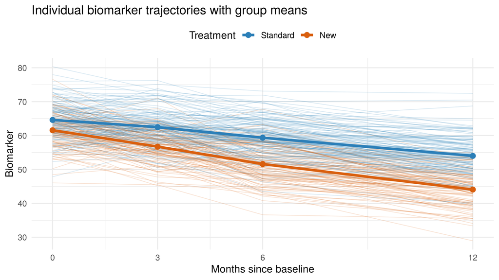

```r
mean_profiles <- data_long |>
  group_by(trt, time_numeric) |>
  summarise(mean = mean(biomarker), se = sd(biomarker) / sqrt(n()), .groups = "drop")

p_traj <- ggplot(data_long, aes(time_numeric, biomarker)) +
  geom_line(aes(group = id, colour = trt), alpha = 0.18, linewidth = 0.35) +
  geom_line(data = mean_profiles, aes(y = mean, colour = trt), linewidth = 1.4) +
  geom_point(data = mean_profiles, aes(y = mean, colour = trt), size = 2.6) +
  scale_colour_manual(values = trt_cols) +
  scale_x_continuous(breaks = c(0, 3, 6, 12)) +
  labs(x = "Months since baseline", y = "Biomarker", colour = "Treatment",
       title = "Individual biomarker trajectories with group means") +
  theme(legend.position = "top")

save_fig(p_traj, "01_trajectories.png")
```

```r
mean_profiles |>
  select(-se) |>
  pivot_wider(names_from = time_numeric, values_from = mean, names_prefix = "Month ") |>
  mutate(`Change 0→12` = `Month 12` - `Month 0`) |>
  kable(digits = 1)
```

| trt | Month 0 | Month 3 | Month 6 | Month 12 | Change 0→12 |
| --- | --- | --- | --- | --- | --- |
| Standard | 64.6 | 62.5 | 59.4 | 54.0 | -10.6 |
| New | 61.6 | 56.7 | 51.6 | 44.1 | -17.5 |

**What the plot shows**

- **Between-subject variability is large.** Baseline values range from about 46 to 80, and patients keep their relative position over time (lines run roughly parallel), which points to a strong patient-level random intercept.
- **Within-subject trend.** Almost all trajectories decline, roughly linearly in time, with visit-to-visit noise around each patient’s line.
- **Treatment difference.** The new-treatment group falls by about 17.5 units over 12 months compared with about 10.6 units under standard treatment, so the group means diverge over time. The new group also starts about 3 units lower.

These are descriptive impressions; the models below test them formally.

# 4 Repeated-measures ANOVA

Treatment is a between-subject factor and visit a within-subject factor. The classical repeated-measures ANOVA assumes **sphericity** (implied by compound symmetry: equal variances at all visits and equal correlation between any two visits).

```r
anova_rm <- aov_car(
  biomarker ~ trt * time_factor + Error(id / time_factor),
  data = data_long,
  anova_table = list(correction = "none", es = "pes")
)
anova_rm
```

```
## Anova Table (Type 3 tests)
##
## Response: biomarker
##            Effect     df   MSE          F  pes p.value
## 1             trt 1, 238 80.41 129.16 *** .352   <.001
## 2     time_factor 3, 714 11.96 721.89 *** .752   <.001
## 3 trt:time_factor 3, 714 11.96  42.53 *** .152   <.001
## ---
## Signif. codes:  0 '***' 0.001 '**' 0.01 '*' 0.05 '+' 0.1 ' ' 1
```

```r
emmeans(anova_rm, ~ trt | time_factor) |> as_tibble() |>
  select(time_factor, trt, emmean, SE) |> kable(digits = 2)
```

| time_factor | trt | emmean | SE |
| --- | --- | --- | --- |
| X0 | Standard | 64.61 | 0.46 |
| X0 | New | 61.56 | 0.52 |
| X3 | Standard | 62.47 | 0.44 |
| X3 | New | 56.73 | 0.50 |
| X6 | Standard | 59.36 | 0.49 |
| X6 | New | 51.60 | 0.55 |
| X12 | Standard | 54.00 | 0.48 |
| X12 | New | 44.06 | 0.54 |

- **Time** (F = 721.9, p < 0.001): the biomarker changes strongly over follow-up.
- **Treatment** (F = 129.2, p < 0.001): averaged over visits, the new-treatment group is lower. Part of this is the baseline imbalance noted above, so the main effect alone should not be read as a treatment effect.
- **Treatment × time** (F = 42.5, p < 0.001): the groups change at different rates. This interaction is the effect of interest: the gap grows from about 3 units at baseline to about 10 units at 12 months.

## 4.1 Checking the assumptions

```r
summary(anova_rm)$sphericity.tests
```

```
##                 Test statistic p-value
## time_factor            0.99763 0.98967
## trt:time_factor        0.99763 0.98967
```

```r
summary(anova_rm)$pval.adjustments
```

```
##                    GG eps    Pr(>F[GG])   HF eps    Pr(>F[HF])
## time_factor     0.9984298 2.431006e-215 1.012567 1.127983e-215
## trt:time_factor 0.9984298  2.943392e-25 1.012567  2.711577e-25
## attr(,"na.action")
## (Intercept)         trt
##           1           2
## attr(,"class")
## [1] "omit"
```

```r
nice(anova_rm, correction = "GG")
```

| Effect | df | MSE | F | pes | p.value |
| --- | --- | --- | --- | --- | --- |
| trt | 1, 238 | 80.41 | 129.16 *** | .352 | <.001 |
| time_factor | 3.00, 712.88 | 11.98 | 721.89 *** | .752 | <.001 |
| trt:time_factor | 3.00, 712.88 | 11.98 | 42.53 *** | .152 | <.001 |

```r
wide_bio <- data_wide |> select(bio_0, bio_3, bio_6, bio_12)
round(apply(wide_bio, 2, var), 1)       # variances by visit
```

```
##  bio_0  bio_3  bio_6 bio_12
##   30.4   34.1   46.5   54.7
```

```r
round(cor(wide_bio), 2)                 # correlations between visits
```

```
##        bio_0 bio_3 bio_6 bio_12
## bio_0   1.00  0.60  0.63   0.62
## bio_3   0.60  1.00  0.69   0.71
## bio_6   0.63  0.69  1.00   0.75
## bio_12  0.62  0.71  0.75   1.00
```

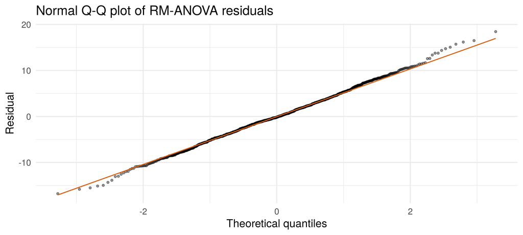

```r
rm_resid <- tibble(resid = residuals(anova_rm))

p_qq <- ggplot(rm_resid, aes(sample = resid)) +
  stat_qq(alpha = 0.4, size = 0.9) + stat_qq_line(colour = "#D95F0E") +
  labs(title = "Normal Q-Q plot of RM-ANOVA residuals",
       x = "Theoretical quantiles", y = "Residual")
save_fig(p_qq, "02_rmanova_qq.png", h = 3.6)
```

**Assessment.**

- **Normality:** residuals from the repeated-measures model lie close to the Q-Q line, with only slight deviation in the tails.
- **Sphericity:** this is the condition the within-subject F-tests actually require. It holds: Mauchly’s test is far from significant (p = 0.99) and the Greenhouse–Geisser ε ≈ 1.00, so the corrected tests are identical to the uncorrected ones.
- **Compound symmetry** is a stronger, sufficient condition, and it does *not* strictly hold. The pooled variance grows from about 30 at baseline to about 55 at 12 months, partly because the two groups drift apart. The between-visit correlations are similar (0.60–0.75) but not equal. Sphericity can hold without compound symmetry, so the F-tests remain valid.
- **Other limits:** RM-ANOVA treats time as unordered categories, cannot adjust for continuous covariates such as age, and drops any patient with a missing visit. The mixed models below address all three.

# 5 Linear mixed model with a random intercept

$$\text{bio}_{ij} = \beta_0 + \beta_1 t_{ij} + \beta_2\,\text{trt}_i +
\beta_3\,(t_{ij}\times\text{trt}_i)
+ \beta_4\,\text{age}^{c}_i + \beta_5\,\text{sex}_i + b_{0i} +
\varepsilon_{ij},
\qquad b_{0i}\sim N(0,\sigma_b^2),\ \varepsilon_{ij}\sim N(0,\sigma^2)$$

Age is **centred at the sample mean** (62.8 years), so the intercept is the expected baseline value for a female patient of average age under standard treatment, rather than a value at age 0.

```r
model_ri <- lmer(
  biomarker ~ time_numeric * treatment + age_c + sex + (1 | id),
  data = data_long, REML = TRUE
)

fixef_tab <- tidy(model_ri, effects = "fixed", conf.int = TRUE) |>
  select(term, estimate, std.error, conf.low, conf.high, p.value)
kable(fixef_tab, digits = c(0, 3, 3, 3, 3, 4),
      col.names = c("Term", "Estimate", "SE", "95% CI low", "95% CI high", "p"))
```

| Term | Estimate | SE | 95% CI low | 95% CI high | p |
| --- | --- | --- | --- | --- | --- |
| (Intercept) | 64.615 | 0.505 | 63.621 | 65.609 | 0.0000 |
| time_numeric | -0.898 | 0.034 | -0.965 | -0.832 | 0.0000 |
| treatment | -3.800 | 0.629 | -5.037 | -2.562 | 0.0000 |
| age_c | 0.136 | 0.038 | 0.060 | 0.212 | 0.0005 |
| sex | 0.524 | 0.567 | -0.592 | 1.640 | 0.3562 |
| time_numeric:treatment | -0.558 | 0.051 | -0.658 | -0.458 | 0.0000 |

```r
b <- fixef(model_ri)
slopes <- c(Standard = b[["time_numeric"]],
            New      = b[["time_numeric"]] + b[["time_numeric:treatment"]])
round(slopes, 3)
```

```
## Standard      New
##   -0.898   -1.457
```

**Interpretation**

- Under standard treatment the biomarker falls by about **0.90 units per month**.
- The **time × treatment interaction (−0.56 per month, 95% CI shown above)** means the new-treatment group declines faster, by about **1.46 units per month**. Over 12 months that adds up to roughly 6.7 extra units of reduction.
- The `treatment` coefficient (−3.8) is the group difference **at baseline**. It reflects the baseline imbalance, not an effect of treatment, because no treatment has acted at month 0.
- **Age:** each additional year is associated with a slightly higher biomarker (≈ 0.14 units). **Sex:** the confidence interval is wide and includes zero, so there is no clear sex difference.

## 5.1 Variance components and ICC

```r
vc <- as.data.frame(VarCorr(model_ri))
sigma2_b <- vc$vcov[vc$grp == "id"]
sigma2_e <- vc$vcov[vc$grp == "Residual"]
icc <- sigma2_b / (sigma2_b + sigma2_e)

tibble(Component = c("Between-patient (random intercept)", "Within-patient (residual)"),
       Variance  = c(sigma2_b, sigma2_e),
       SD        = sqrt(c(sigma2_b, sigma2_e))) |>
  kable(digits = 2)
```

| Component | Variance | SD |
| --- | --- | --- |
| Between-patient (random intercept) | 16.11 | 4.01 |
| Within-patient (residual) | 12.07 | 3.47 |

```r
round(icc, 3)
```

```
## [1] 0.572
```

The **ICC ≈ 0.57**. After accounting for time, treatment, age and sex, 57% of the remaining variance is due to stable differences between patients. Two measurements from the same patient therefore correlate at about 0.57. Ignoring this clustering (ordinary regression) would understate the standard errors of between-patient effects.

**The random intercept** $b_{0i}$ is each patient’s personal deviation from the population baseline level. Patients differ in where they start, with an SD of about 4 units, but in this model they all share the same treatment-specific rate of change.

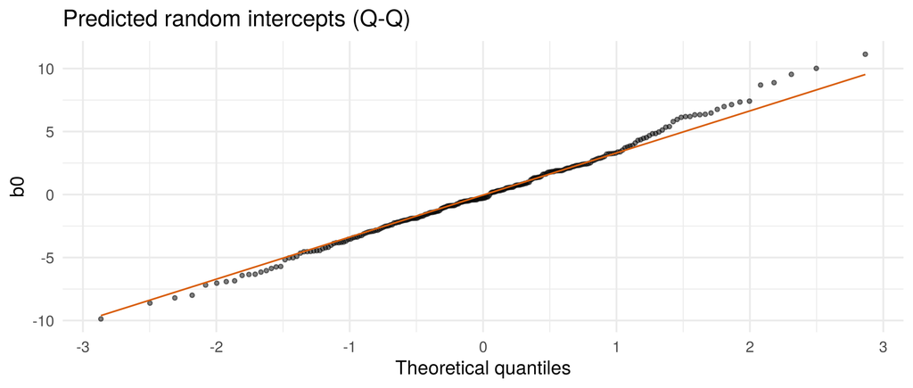

```r
re <- ranef(model_ri)$id |> rownames_to_column("id") |> rename(b0 = `(Intercept)`)
p_re <- ggplot(re, aes(sample = b0)) +
  stat_qq(alpha = 0.5, size = 1) + stat_qq_line(colour = "#D95F0E") +
  labs(title = "Predicted random intercepts (Q-Q)", x = "Theoretical quantiles", y = "b0")
save_fig(p_re, "03_random_intercepts_qq.png", h = 3.4)
```

# 6 Do patients differ in their rate of change? (random slopes)

```r
model_rs <- lmer(
  biomarker ~ time_numeric * treatment + age_c + sex + (time_numeric | id),
  data = data_long, REML = TRUE
)
VarCorr(model_rs)
```

```
##  Groups   Name         Std.Dev. Corr
##  id       (Intercept)  3.830639
##           time_numeric 0.035197 1.000
##  Residual              3.470108
```

```r
isSingular(model_rs)
```

```
## [1] TRUE
```

The two models have the same fixed effects, so I compare them with a likelihood-ratio test on the **REML** fits (`refit = FALSE`). The ML refit used by default is meant for comparing fixed effects.

```r
lrt <- anova(model_ri, model_rs, refit = FALSE)
lrt
```

|  | npar | AIC | BIC | logLik | deviance | Chisq | Df | Pr(>Chisq) |
| --- | --- | --- | --- | --- | --- | --- | --- | --- |
| model_ri | 8 | 5582.594 | 5621.530 | -2783.297 | 5566.594 | NA | NA | NA |
| model_rs | 10 | 5584.982 | 5633.651 | -2782.491 | 5564.982 | 1.612453 | 2 | 0.4465399 |

```r
# The null hypothesis puts the slope variance on the boundary of its space
# (sigma^2_slope = 0), so the naive chi-square(2) p-value is conservative.
# The correct reference is a 50:50 mixture of chi-square(1) and chi-square(2).
chisq <- lrt$Chisq[2]
p_mixture <- 0.5 * pchisq(chisq, 1, lower.tail = FALSE) +
             0.5 * pchisq(chisq, 2, lower.tail = FALSE)
round(c(LRT = chisq, p_naive = lrt$`Pr(>Chisq)`[2], p_mixture = p_mixture), 3)
```

```
##       LRT   p_naive p_mixture
##     1.612     0.447     0.325
```

**Which model?** The random-intercept model is preferred.

- *Statistically:* the random-slope variance is essentially zero (a singular, boundary fit). The likelihood-ratio test is non-significant even with the correct boundary-adjusted mixture p-value, and AIC/BIC do not favour the larger model.
- *Practically:* patients differ mainly in **level**, not in **rate** of decline. The simpler model is stable, easier to explain, and gives the same fixed effects. Its residual plot (below) shows no structure left over.

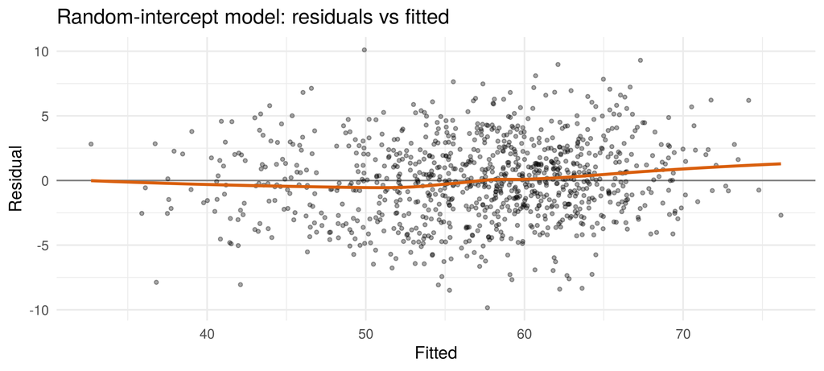

```r
p_fit <- tibble(fitted = fitted(model_ri), resid = resid(model_ri)) |>
  ggplot(aes(fitted, resid)) +
  geom_hline(yintercept = 0, colour = "grey50") +
  geom_point(alpha = 0.35, size = 1) +
  geom_smooth(se = FALSE, colour = "#D95F0E", method = "loess") +
  labs(title = "Random-intercept model: residuals vs fitted", x = "Fitted", y = "Residual")
save_fig(p_fit, "04_lmm_residuals.png", h = 3.6)
```

# 7 Generalized estimating equations

GEE models the **population-averaged** mean and treats the within-patient correlation as a nuisance. Robust (sandwich) standard errors keep inference valid even when the working correlation is misspecified.

```r
data_gee <- data_long |> arrange(id, time_numeric)

gee_ind  <- geeglm(biomarker ~ time_numeric * treatment, id = id, data = data_gee,
                   family = gaussian, corstr = "independence")
gee_exch <- geeglm(biomarker ~ time_numeric * treatment, id = id, data = data_gee,
                   family = gaussian, corstr = "exchangeable")
gee_ar1  <- geeglm(biomarker ~ time_numeric * treatment, id = id, data = data_gee,
                   family = gaussian, corstr = "ar1")

gee_tab <- map_dfr(
  list(Independence = gee_ind, Exchangeable = gee_exch, `AR(1)` = gee_ar1),
  ~ tidy(.x, conf.int = TRUE), .id = "Working correlation"
) |>
  select(`Working correlation`, term, estimate, std.error, conf.low, conf.high)
kable(gee_tab, digits = 3)
```

| Working correlation | term | estimate | std.error | conf.low | conf.high |
| --- | --- | --- | --- | --- | --- |
| Independence | (Intercept) | 64.828 | 0.419 | 64.007 | 65.649 |
| Independence | time_numeric | -0.898 | 0.034 | -0.964 | -0.832 |
| Independence | treatment | -3.693 | 0.611 | -4.891 | -2.496 |
| Independence | time_numeric:treatment | -0.558 | 0.049 | -0.654 | -0.462 |
| Exchangeable | (Intercept) | 64.828 | 0.419 | 64.007 | 65.649 |
| Exchangeable | time_numeric | -0.898 | 0.034 | -0.964 | -0.832 |
| Exchangeable | treatment | -3.693 | 0.611 | -4.891 | -2.496 |
| Exchangeable | time_numeric:treatment | -0.558 | 0.049 | -0.654 | -0.462 |
| AR(1) | (Intercept) | 64.693 | 0.432 | 63.846 | 65.539 |
| AR(1) | time_numeric | -0.888 | 0.037 | -0.961 | -0.815 |
| AR(1) | treatment | -3.572 | 0.647 | -4.839 | -2.304 |
| AR(1) | time_numeric:treatment | -0.524 | 0.056 | -0.633 | -0.415 |

```r
c(exchangeable_alpha = gee_exch$geese$alpha, ar1_alpha = gee_ar1$geese$alpha) |> round(3)
```

```
## exchangeable_alpha.alpha          ar1_alpha.alpha
##                    0.584                    0.734
```

```r
sapply(list(Independence = gee_ind, Exchangeable = gee_exch, `AR(1)` = gee_ar1),
       function(m) QIC(m)[c("QIC", "CIC")]) |> round(1)
```

```
##     Independence Exchangeable   AR(1)
## QIC      27818.8      27818.8 27861.8
## CIC          6.2          6.2     6.7
```

**Comparing working correlations.** Independence and exchangeable give the same point estimates. This is expected here: every patient has the same four visit times and treatment is constant within a patient, so weighting by an exchangeable correlation does not change the least-squares solution. Their robust SEs are also nearly identical. AR(1) changes the estimates slightly. QIC mainly reflects the mean model; CIC, the penalty part, is designed for choosing the working correlation. Neither suggests AR(1) is the better choice. The main finding (time × treatment ≈ −0.53 to −0.56) holds under every structure.

## 7.1 Comparison with the mixed model (like for like)

The task’s GEE has no age or sex, while the mixed model has both. For a fair comparison I also fit the GEE with the **same covariates** as the mixed model.

```r
gee_exch_adj <- geeglm(biomarker ~ time_numeric * treatment + age_c + sex, id = id,
                       data = data_gee, family = gaussian, corstr = "exchangeable")

cmp <- full_join(
  tidy(model_ri, effects = "fixed") |> select(term, LMM = estimate, LMM_SE = std.error),
  tidy(gee_exch_adj) |> select(term, GEE = estimate, GEE_robust_SE = std.error),
  by = "term"
)
kable(cmp, digits = 3)
```

| term | LMM | LMM_SE | GEE | GEE_robust_SE |
| --- | --- | --- | --- | --- |
| (Intercept) | 64.615 | 0.505 | 64.615 | 0.481 |
| time_numeric | -0.898 | 0.034 | -0.898 | 0.034 |
| treatment | -3.800 | 0.629 | -3.800 | 0.598 |
| age_c | 0.136 | 0.038 | 0.136 | 0.038 |
| sex | 0.524 | 0.567 | 0.524 | 0.568 |
| time_numeric:treatment | -0.558 | 0.051 | -0.558 | 0.049 |

With the same covariates, the mixed model and GEE agree almost exactly. **This is expected, not a coincidence.** For a continuous outcome with an **identity link**, the subject-specific coefficients of a linear mixed model are the same as the population-averaged coefficients: averaging $\beta_0 + b_{0i} + \dots$ over patients just removes $b_{0i}$. The two approaches still answer different questions:

- **GEE:** how does the *average* biomarker in the population change, and how does that average differ between treatment groups? Robust to misspecified correlation, but makes no statements about individuals and needs data missing completely at random.
- **Mixed model:** how does *a given patient’s* biomarker change? It models the correlation explicitly, gives patient-level predictions, and stays valid when data are missing at random.

With a **non-linear link** (e.g. logistic regression for a binary outcome) the two sets of coefficients differ: subject-specific effects are larger in magnitude than population-averaged ones. The choice between them is then substantive, not just technical.

# 8 Survival: Kaplan–Meier and log-rank test

```r
km_fit <- survfit(Surv(follow, death) ~ trt, data = data_wide)
km_fit
```

```
## Call: survfit(formula = Surv(follow, death) ~ trt, data = data_wide)
##
##                n events median 0.95LCL 0.95UCL
## trt=Standard 134     60   3.46    2.93      NA
## trt=New      106     31     NA    4.55      NA
```

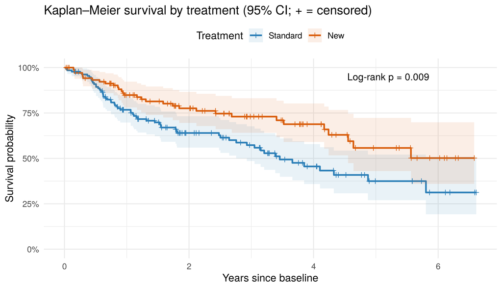

```r
km_df <- tidy(km_fit) |>
  mutate(trt = factor(sub("trt=", "", strata), levels = c("Standard", "New")))
km_start <- km_df |> distinct(trt) |>
  mutate(time = 0, estimate = 1, conf.low = 1, conf.high = 1, n.censor = 0)
km_df <- bind_rows(km_start, km_df) |> arrange(trt, time) |>
  group_by(trt) |> mutate(time_next = lead(time, default = max(time))) |> ungroup()

lr <- survdiff(Surv(follow, death) ~ trt, data = data_wide)
lr_p <- pchisq(lr$chisq, df = 1, lower.tail = FALSE)

p_km <- ggplot(km_df, aes(time, estimate, colour = trt, fill = trt)) +
  geom_step(linewidth = 0.9) +
  geom_rect(aes(xmin = time, xmax = time_next,
                ymin = conf.low, ymax = conf.high), alpha = 0.10, colour = NA) +
  geom_point(data = filter(km_df, n.censor > 0), shape = 3, size = 1.6) +
  scale_colour_manual(values = trt_cols) + scale_fill_manual(values = trt_cols) +
  scale_y_continuous(labels = scales::percent, limits = c(0, 1)) +
  annotate("text", x = 5.2, y = 0.95, label = sprintf("Log-rank p = %.3f", lr_p)) +
  labs(x = "Years since baseline", y = "Survival probability",
       colour = "Treatment", fill = "Treatment",
       title = "Kaplan–Meier survival by treatment (95% CI; + = censored)") +
  theme(legend.position = "top")
save_fig(p_km, "05_kaplan_meier.png", h = 4.6)
```

```r
summary(km_fit, times = c(1, 2, 3, 5))$table
```

```
##              records n.max n.start events    rmean se(rmean)   median  0.95LCL
## trt=Standard     134   134     134     60 3.674996 0.2558741 3.457002 2.928374
## trt=New          106   106     106     31 4.655645 0.2778709       NA 4.554141
##              0.95UCL
## trt=Standard      NA
## trt=New           NA
```

```r
summary(km_fit, times = c(1, 2, 3, 5)) |>
  (\(s) tibble(Treatment = sub("trt=", "", s$strata), Year = s$time,
               `At risk` = s$n.risk, Survival = s$surv,
               `95% CI` = sprintf("%.2f–%.2f", s$lower, s$upper)))() |>
  kable(digits = 2)
```

| Treatment | Year | At risk | Survival | 95% CI |
| --- | --- | --- | --- | --- |
| Standard | 1 | 91 | 0.77 | 0.70–0.84 |
| Standard | 2 | 54 | 0.64 | 0.56–0.73 |
| Standard | 3 | 40 | 0.57 | 0.49–0.68 |
| Standard | 5 | 9 | 0.37 | 0.27–0.52 |
| New | 1 | 77 | 0.85 | 0.78–0.92 |
| New | 2 | 58 | 0.78 | 0.69–0.87 |
| New | 3 | 39 | 0.73 | 0.64–0.83 |
| New | 5 | 13 | 0.56 | 0.43–0.72 |

```r
lr
```

```
## Call:
## survdiff(formula = Surv(follow, death) ~ trt, data = data_wide)
##
##                N Observed Expected (O-E)^2/E (O-E)^2/V
## trt=Standard 134       60     47.6      3.23       6.8
## trt=New      106       31     43.4      3.54       6.8
##
##  Chisq= 6.8  on 1 degrees of freedom, p= 0.009
```

**Findings.** The curves separate within the first year, when about half of all deaths occur, and stay apart. Estimated 3-year survival is 57% under standard treatment and 73% under the new treatment. Median survival is 3.5 years (95% CI from 2.9) under standard treatment and is not reached under the new treatment. Survival is consistently higher in the new-treatment group. Under standard treatment 60 of 134 patients died, compared with 31 of 106 under the new treatment. The log-rank test rejects equal survival distributions (χ² = 6.8, 1 df, p = 0.009). The new group had fewer deaths than expected under the null hypothesis, and the standard group more. Few patients remain at risk after about five years, so the right-hand ends of the curves are imprecise.

# 9 Survival: Cox proportional hazards model

```r
cox1 <- coxph(Surv(follow, death) ~ treatment + age + sex, data = data_wide)
hr_table <- function(m) {
  tidy(m, exponentiate = TRUE, conf.int = TRUE) |>
    transmute(Term = term, HR = estimate, `95% CI low` = conf.low,
              `95% CI high` = conf.high, p = p.value)
}
kable(hr_table(cox1), digits = 3)
```

| Term | HR | 95% CI low | 95% CI high | p |
| --- | --- | --- | --- | --- |
| treatment | 0.561 | 0.362 | 0.870 | 0.010 |
| age | 1.032 | 1.002 | 1.064 | 0.037 |
| sex | 1.131 | 0.746 | 1.713 | 0.562 |

- **Treatment: HR ≈ 0.56 (95% CI 0.36–0.87).** At any time, a patient on the new treatment has an estimated 44% lower instantaneous risk of death than a comparable patient (same age and sex) on standard treatment. The CI excludes 1.
- **Age: HR ≈ 1.03 per year**, i.e. about 3% higher hazard per year of age (≈ 37% per decade); the lower CI limit is close to 1.
- **Sex:** HR ≈ 1.13 with a wide CI that includes 1, so there is no evidence of a sex difference.

## 9.1 Proportional hazards assumption

The model assumes each hazard ratio is **constant over follow-up**. The standard check plots scaled Schoenfeld residuals against time: a flat smooth supports the assumption, while a trend means the effect changes over time. The plots are supported by the Grambsch–Therneau test. For continuous covariates, linearity of the log-hazard (e.g. martingale residuals) and influential observations are also worth checking.

```r
zph1 <- cox.zph(cox1)
zph1
```

```
##            chisq df    p
## treatment 0.0719  1 0.79
## age       0.8605  1 0.35
## sex       0.7530  1 0.39
## GLOBAL    1.5502  3 0.67
```

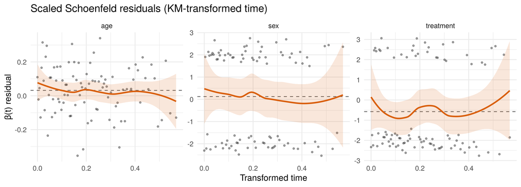

```r
zph_df <- map_dfr(colnames(zph1$y), \(v)
  tibble(var = v, time = zph1$x, resid = zph1$y[, v]))
coef_df <- tibble(var = names(coef(cox1)), beta = coef(cox1))
p_sch <- ggplot(zph_df, aes(time, resid)) +
  geom_hline(data = coef_df, aes(yintercept = beta), colour = "grey40", linetype = "dashed") +
  geom_point(alpha = 0.35, size = 0.9) +
  geom_smooth(method = "loess", se = TRUE, colour = "#D95F0E", fill = "#D95F0E", alpha = 0.15) +
  facet_wrap(~ var, scales = "free_y") +
  labs(title = "Scaled Schoenfeld residuals (KM-transformed time)",
       x = "Transformed time", y = "β(t) residual")
save_fig(p_sch, "06_schoenfeld.png", w = 10, h = 3.6)
```

The dashed line is each covariate’s estimated log hazard ratio. Under proportional hazards, the smooth $\hat\beta(t)$ should stay flat around it. None of the smooths shows a clear trend (the wiggles stay inside wide bands), and none of the tests is significant (global p ≈ 0.67), so proportional hazards is a reasonable assumption here.

# 10 Is the baseline biomarker prognostic?

```r
cox2 <- coxph(Surv(follow, death) ~ treatment + age + sex + bio_0, data = data_wide)
kable(hr_table(cox2), digits = 3)
```

| Term | HR | 95% CI low | 95% CI high | p |
| --- | --- | --- | --- | --- |
| treatment | 0.609 | 0.389 | 0.955 | 0.031 |
| age | 1.029 | 0.998 | 1.060 | 0.067 |
| sex | 1.077 | 0.707 | 1.641 | 0.728 |
| bio_0 | 1.035 | 0.994 | 1.077 | 0.094 |

```r
# HR per 10-unit higher baseline biomarker (a more readable scale)
round(exp(10 * c(coef(cox2)["bio_0"], confint(cox2)["bio_0", ])), 2)
```

```
##  bio_0  2.5 % 97.5 %
##   1.41   0.94   2.10
```

```r
AIC(cox1, cox2)
```

|  | df | AIC |
| --- | --- | --- |
| cox1 | 3 | 882.1380 |
| cox2 | 4 | 881.3502 |

```r
anova(cox1, cox2)   # likelihood-ratio test for adding bio_0
```

| loglik | Chisq | Df | Pr(>\|Chi\|) |
| --- | --- | --- | --- |
| -438.0690 | NA | NA | NA |
| -436.6751 | 2.787775 | 1 | 0.094986 |

```r
bind_rows(
  `Treatment + age + sex`         = hr_table(cox1) |> filter(Term == "treatment"),
  `Treatment + age + sex + bio_0` = hr_table(cox2) |> filter(Term == "treatment"),
  .id = "Model"
) |> select(-Term) |> kable(digits = 3)
```

| Model | HR | 95% CI low | 95% CI high | p |
| --- | --- | --- | --- | --- |
| Treatment + age + sex | 0.561 | 0.362 | 0.870 | 0.010 |
| Treatment + age + sex + bio_0 | 0.609 | 0.389 | 0.955 | 0.031 |

**Interpretation**

- Adjusting for the baseline biomarker moves the treatment HR from **0.56 to 0.61**. The new treatment remains protective (CI 0.39–0.96).
- `bio_0` is measured **before treatment starts**, so it cannot be a mediator. Treatment cannot act *through* a value recorded before it began. The change in HR is **confounding adjustment**: the new-treatment group happened to start with lower biomarker values (Section 2). If lower baseline values carry lower risk, part of the crude survival advantage reflects that head start, and adjusting removes it. In a properly randomised trial the adjusted estimate is the more precise of the two.
- **The evidence that `bio_0` is prognostic is weak.** Each 10-unit higher baseline value is associated with about a 41% higher hazard (95% CI 0.94–2.10). The CI includes 1, the likelihood-ratio test gives p ≈ 0.09, and AIC improves by less than 1 point. The direction is plausible; the precision is limited.

## 10.1 How longitudinal biomarkers and survival relate

In clinical studies a biomarker can be (i) a **prognostic marker** of disease severity, (ii) a **mediator** on the causal path from treatment to outcome, or (iii) a candidate **surrogate endpoint**. Here, the new treatment both lowers the biomarker faster (Sections 5–7) and improves survival (Sections 8–9). That is consistent with the biomarker lying on the causal pathway, but these analyses cannot show it.

Answering that question would require modelling the **post-baseline** trajectory. Putting later biomarker values directly into a Cox model as fixed covariates would be wrong: it conditions on the future and creates *immortal-time bias*. The data also show why caution is needed. All 240 patients have a 12-month biomarker value, yet 45 patients died **before** 12 months. That is an artefact of the simulation, but in real data the biomarker would be missing after death (informative dropout). The appropriate tools are:

- a **joint longitudinal–survival model** (e.g. `JMbayes2`, `joineRML`), which links each patient’s current modelled biomarker value or slope to their hazard and handles informative dropout; or
- a **landmark analysis**: among patients alive at a landmark time, use the biomarker history up to that time to predict survival afterwards.

# 11 Summary of findings

| Question | Method | Result |
| --- | --- | --- |
| Does the biomarker change over time? | RM-ANOVA, LMM | Declines in both groups (≈ 0.90 units/month under standard treatment) |
| Does the change differ by treatment? | RM-ANOVA, LMM, GEE | Faster decline under the new treatment: extra −0.56 units/month (≈ −1.46 vs −0.90) |
| Where does the variation lie? | Variance components | ICC ≈ 0.57; patients differ in level, not in rate (random slope variance ≈ 0) |
| Does the new treatment improve survival? | KM, log-rank, Cox | Yes: log-rank p = 0.009; adjusted HR 0.56 (0.36–0.87); PH holds |
| Is baseline biomarker prognostic? | Cox | Weak evidence (CI includes 1); adjusting for it moves the treatment HR to 0.61 (0.39–0.96) |

# 12 What was revised from the original coursework

1. **Mediation claim corrected.** The original text said the treatment HR shifted because part of the effect works “through biomarker levels”. Because `bio_0` is a pre-treatment variable, the shift is confounding adjustment for a baseline imbalance, not mediation.
2. **Sphericity checked.** Mauchly’s test and Greenhouse–Geisser-corrected tests are now reported (sphericity holds, though strict compound symmetry does not), and residuals come from the repeated-measures model rather than from an `lm()` that ignores patients.
3. **Fair GEE-vs-LMM comparison.** The GEE is also fitted with the mixed model’s covariates. The near-identical estimates are explained by the identity link.
4. **Boundary-corrected LRT.** The random-slope test uses REML fits and the χ²₁:χ²₂ mixture reference distribution.
5. **Uncertainty reported.** Standard errors and confidence intervals accompany all fixed effects, and age is centred so the intercept is meaningful.
6. **Schoenfeld residual plots** are now shown, not just described.
7. **Reproducibility.** One R Markdown file runs from the raw data to every table and figure, with package versions recorded in `renv.lock`.